# Untitled

2024-11-04

# page 1

## row

### column

https://www.bls.gov/wsp/overview.htm

The data provides a historical record of annual work stoppages in the U.S. involving 1,000 or more workers, starting from 1947. It includes the following key information:

- The year of the work stoppage.
- The number of work stoppages that began in a given year and those still in effect.
- The number of workers involved (in thousands).
- The number of days of idleness (in thousands) caused by these stoppages.
- The percentage of total working time lost due to these stoppages.

This dataset is focused on capturing the frequency and economic impact of large-scale labor disruptions over time.

direct summary from the website:

The Bureau of Labor Statistics has two types of data about work stoppages: Work Stoppages program data and the Strike Report.

The Work Stoppages program provides monthly and annual data of major work stoppages involving 1,000 or more workers lasting one full shift or longer. The monthly and annual data show the establishment and union(s) involved in the work stoppage along with the location, the number of workers and the days of idleness. The monthly data list all work stoppages involving 1,000 or more workers that occurred during the full calendar month for each month of the year. The annualized data provide statistics, analysis and details of each work stoppage of 1,000 or more workers that occurred during the year. The work stoppages data are gathered from public news sources, such as newspapers and the Internet. The BLS does not distinguish between strikes and lock-outs in the data; both are included in the term “work stoppages”.

### column

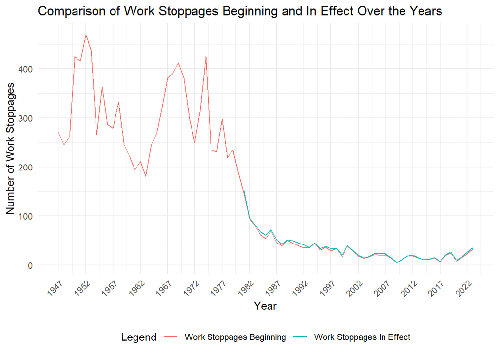

```r
# Load necessary libraries
library(ggplot2)
library(readxl)

# Load the dataset
data4 <- read_excel("cleaned_annual_listing.xlsx", sheet = "Sheet1")

# Ensure Year column is numeric and remove NA values
data4$Year <- as.numeric(data4$Year)
data4 <- data4[!is.na(data4$Year), ]

# Create a dual-line chart with adjusted x-axis labels
ggplot(data4, aes(x = Year)) +
  geom_line(aes(y = Number_of_Work_Stoppages_Beginning, color = "Work Stoppages Beginning", group = 1), na.rm = TRUE) +
  geom_line(aes(y = Number_of_Work_Stoppages_In_Effect, color = "Work Stoppages In Effect", group = 1), na.rm = TRUE) +
  labs(title = "Comparison of Work Stoppages Beginning and In Effect Over the Years",
       x = "Year",
       y = "Number of Work Stoppages",
       color = "Legend") +
  theme_minimal() +
  scale_x_continuous(breaks = seq(min(data4$Year, na.rm = TRUE), max(data4$Year, na.rm = TRUE), by = 5)) + # Show every 5th year
  theme(axis.text.x = element_text(angle = 45, hjust = 1))+ # Rotate x-axis labels
  theme(legend.position = "bottom"  # Options: "bottom", "top", "left", "right" or (x, y) coordinates
  )
```

# page 2

## row

### column

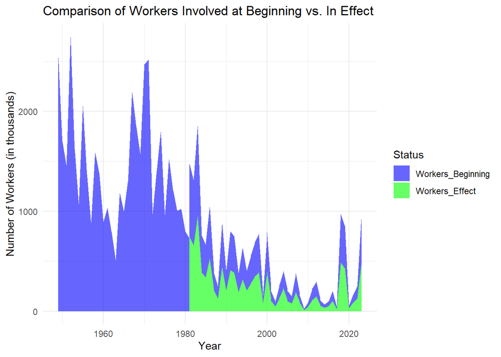

```r
# Load necessary libraries
library(ggplot2)
library(readxl)
library(tidyr)

# Replace with your data loading path if needed
data <- read_excel("cleaned_annual_listing.xlsx", sheet = "Sheet1")

# Clean and select necessary columns
data <- data[3:nrow(data), c(1, 4, 5)]  # Adjust to skip header rows and select Year, Workers_Beginning, Workers_Effect
colnames(data) <- c("Year", "Workers_Beginning", "Workers_Effect")

# Convert columns to appropriate types
data$Year <- as.integer(gsub("\\D", "", data$Year))
data$Workers_Beginning <- as.numeric(gsub(",", "", data$Workers_Beginning))
data$Workers_Effect <- as.numeric(gsub(",", "", data$Workers_Effect))

# Reshape data for ggplot
data_long <- pivot_longer(data, cols = c("Workers_Beginning", "Workers_Effect"), names_to = "Status", values_to = "Workers")

# Plot the stacked area chart
ggplot(data_long, aes(x = Year, y = Workers, fill = Status)) +
  geom_area(alpha = 0.6) +
  labs(title = "Comparison of Workers Involved at Beginning vs. In Effect",
       x = "Year",
       y = "Number of Workers (in thousands)") +
  scale_fill_manual(values = c("Workers_Beginning" = "blue", "Workers_Effect" = "green")) +
  theme_minimal()
```